# Lab-03

Janish Parikh

20/08/2020

Q. 1: Parameter estimation

1.1)Estimate the unknown parameter θ from a sample X = (3, 3, 3, 3, 3, 7, 7, 7) drawn from a discrete probability distribution with following probability mass function (PMF), P(3) = θ P(7) = 1 − θ

```r
X<-c(3,3,3,3,3,7,7,7)
```

1. Compute the method of moments (MoM) estimator

```r
mom_estimator<-function(sample = numeric()){
#kth population moment = kth sample moment
#nu1 = E(X)
#m1 = sample_mean
theta<-numeric()
m1<-mean(sample)
#nu1=3*theta + 7*(1-theta)
theta<-(7-m1)/4
#cat("Estimated parameter with MoM:", theta)
return(theta)}
mom_estimator(X)
```

```
## [1] 0.625
```

(b)Compute the maximum likelihood estimator (MLE)

```r
#discrete case
mle_estimator<-function(sample=numeric()){
  k<-sum(sample(sample==3))
  theta1<-k/length(sample)
  #cat("Estimated parameter with MLE:", theta1)
  return(theta1)}
mle_estimator(X)
```

```
## [1] 0.625
```

(c)Estimate the standard error of each estimator of θ.

```r
std_error<-function(sample=numeric()){
  s<-sd(X)/(abs(3-7)*sqrt(length(sample)))
  cat("standard error for estimated param: ", s)}
std_error(X)
```

```
## standard error for estimated param:  0.1829813
```

1.2) The number of times a computer code is executed until it runs without errors has a Geometric distribution with unknown parameter p. For 5 independent computer projects, a student records the following number of runs: 3 7 5 3 2.

```r
runs<-c(3,7,5,3,2)
```

Estimate p (a) by the MoM

```r
mom_estimator1<-function(sample=numeric()){
  p<-1/mean(sample)
return(p)}
mom_estimator1(runs)
```

```
## [1] 0.25
```

```r
#mle_estimator1<-function(sample=numeric()){
#p1<-k/sum(runs)
#return(p1)}
#mle_estimator1(runs)
```

Question-02 : Confidence Interval

2.1) In order to ensure efficient usage of a server, it is necessary to estimate the mean number of concurrent users.

According to records, the average number of concurrent users at 100 randomly selected times is 37.7, with a standard deviation σ = 9.2.

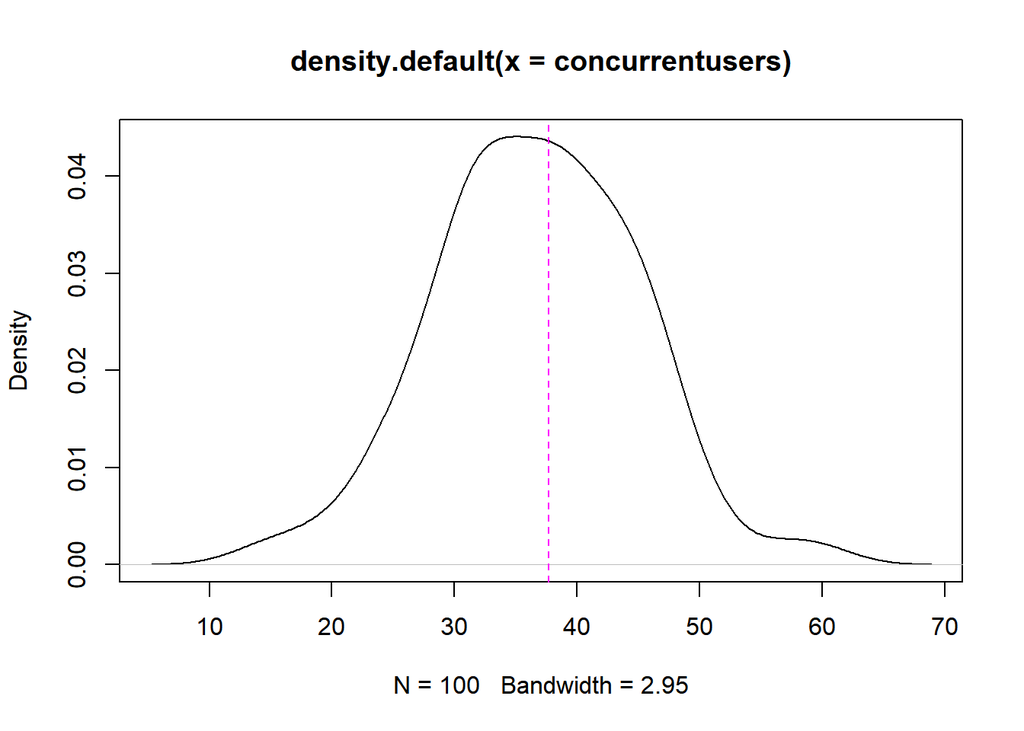

```r
pop_mean <- 37.7
pop_sd <- 9.2
concurrentusers<-rnorm(100, mean = pop_mean, sd =pop_sd)
y<-seq(1:100)
dataF<-as.data.frame(cbind("users"=concurrentusers,"index" = y))
plot(density(concurrentusers))
abline(v=pop_mean, lty =2, col ='magenta')
```

Construct a 90% confidence interval for the expectation of the number of concurrent users.

```r
#This is the case where both mean and sd are specified by the user
confidence_interval1<-function(mean,sd, n=100){
   #90% confidence interval
  alpha<-0.1

  #getting z(alpha/2)
  zscore<-qnorm(1-(alpha/2))
  margin_of_error<-zscore*(sd/sqrt(n))
  ci<-c("Lower"=mean(concurrentusers)-margin_of_error, "Upper"=mean(concurrentusers)+margin_of_error)
  sp<-ggplot(data=dataF, aes(x=index,y=users))+
    geom_point(col='magenta', alpha=0.5)+
    geom_hline(mapping = NULL, yintercept = mean, lty=1, color ="orange")+
    geom_hline(mapping = NULL, yintercept = ci[1], lty=2, color= 'red') +
    geom_hline(mapping = NULL, yintercept = ci[2], lty=2, color="green")+
    geom_text(x=7, y=pop_mean, label = "Population Mean")+
    geom_text(x=100, y=ci[1], label = "A")+
    geom_text(x=100, y=ci[2], label = "B")+
    labs(y = "No of concurrent users", x = "Index", title =  "90% Confidence Interval")
plot(sp)
  return(ci)}
```

Make generalized program for user-specified values of mean and standard deviation.

```r
ci<-confidence_interval1(mean =pop_mean,sd=pop_sd)
```

[figure not shown]

```r
print(ci)
```

```
##    Lower    Upper
## 35.12017 38.14670
```

```r
rm(list=ls())
```

Understanding how for large sample t distribution merges to normal

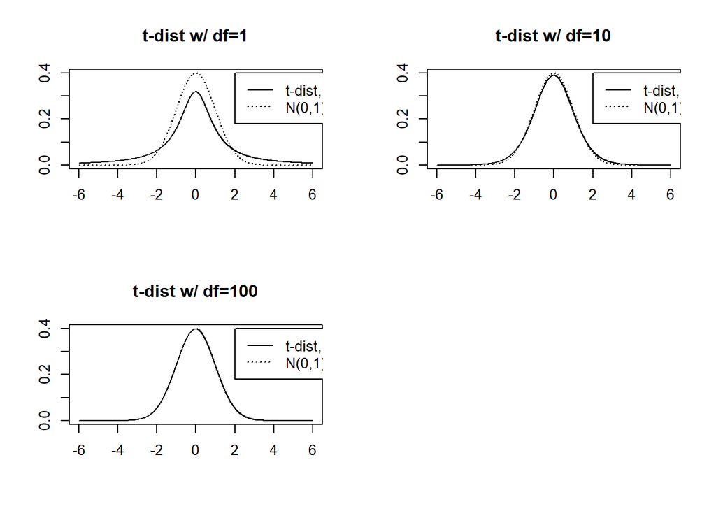

```r
par(mfrow=c(2,2))
plot(seq(-6,6,length=10000),dnorm(seq(-6,6,length=10000)),
type="l",lty=3,ylab="",xlab="",main="t-dist w/ df=1")
lines(seq(-6,6,length=10000),dt(seq(-6,6,length=10000),df=1),
type="l",ylab="",xlab="")
legend(x=2,y=.4,lty=c(1,3),legend=c("t-dist, df=1","N(0,1)"))

plot(seq(-6,6,length=10000),dnorm(seq(-6,6,length=10000)),
type="l",lty=3,ylab="",xlab="",main="t-dist w/ df=10")
lines(seq(-6,6,length=10000),dt(seq(-6,6,length=10000),df=10),
type="l",ylab="",xlab="")
legend(x=2,y=.4,lty=c(1,3),legend=c("t-dist, df=10","N(0,1)"))

plot(seq(-6,6,length=10000),dnorm(seq(-6,6,length=10000)),
type="l",lty=3,ylab="",xlab="",main="t-dist w/ df=100")
lines(seq(-6,6,length=10000),dt(seq(-6,6,length=10000),df=100),
type="l",ylab="",xlab="")
legend(x=2,y=.4,lty=c(1,3),legend=c("t-dist, df=100","N(0,1)"))
```

2.2) Salaries of entry-level computer engineers have Normal distribution with un- known mean and variance.Three randomly selected computer engineers have salaries (INR): 30000, 50000, 70000.

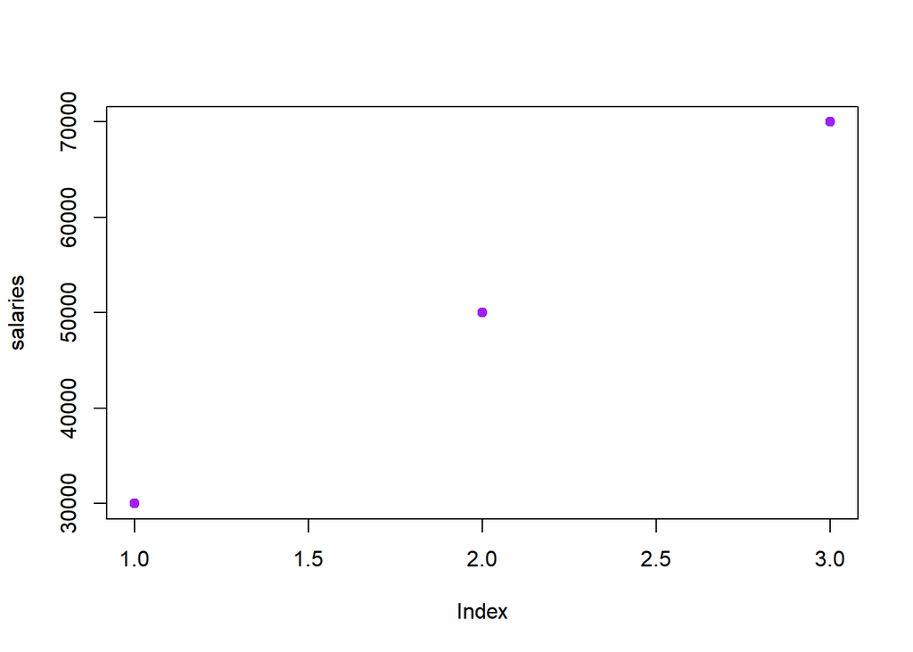

```r
salaries<-c(30000,50000,70000)
sample_mean<-mean(salaries)
sample_sd<-sd(salaries)
plot(salaries, pch=19, col='purple')
```

Construct a 90% confidence interval for the average salary of an entry-level computer engineer.

```r
confidence_interval2<- function(data=numeric(),conf.level=0.9){
  sample_mean<-mean(data)
  sample_sd<-sd(data)
  n = length(data)
  y <- seq(1:n)
  dataF<-as.data.frame(cbind("Salaries"=data,"index" = y))
  deg_free<-n-1
  index<-seq(1:n)
  alpha<-1-conf.level
  talpha<-qt(1-(alpha/2),df=deg_free)
  se<- sample_sd/sqrt(n)
  margin_of_error<-talpha*se
  ci<-c("Lower"=sample_mean-margin_of_error,
        "Upper"=sample_mean+margin_of_error)
  sp<-ggplot(data=dataF, aes(x=index,y=data))+
    geom_point(col='magenta', alpha=0.5)+
    geom_hline(mapping = NULL, yintercept = sample_mean, lty=1, color ="pink")+
    geom_hline(mapping = NULL, yintercept = ci[1], lty=2, color= 'red') +
    geom_hline(mapping = NULL, yintercept = ci[2], lty=2, color="green")+
    geom_text(x=3, y=sample_mean, label = "Mean")+
    geom_text(x=3, y=ci[1], label = "A")+
    geom_text(x=3 ,y=ci[2], label = "B")+
    labs(y = "Starting salries for engineers", x = "Index", title =  "90% Confidence Interval")
plot(sp)
  return(ci)}
```

Present a generalized program for a user-specified salaries (both number & values).

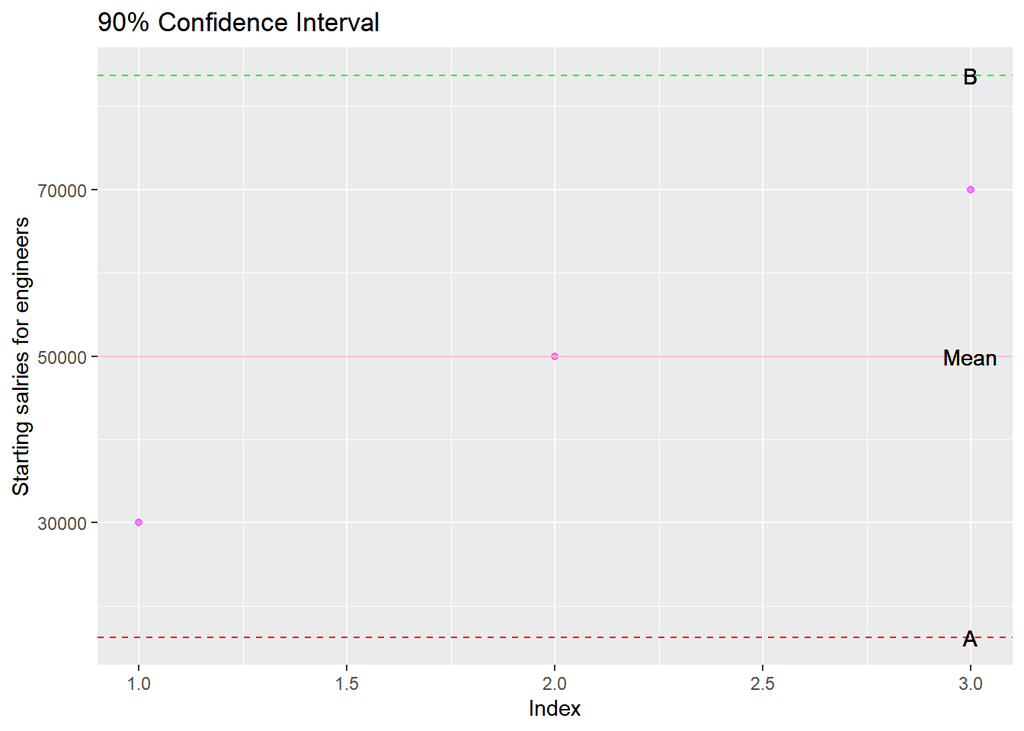

```
##    Lower    Upper
## 16282.91 83717.09
```

```r
confidence_interval2(salaries)
```

```r
rm(list = ls())
```